# Importing Python Libraries

```python
import numpy as np
import pandas as pd
import matplotlib.pyplot as plt
import seaborn as sns
import sqlite3 as sql
import warnings
warnings.filterwarnings('ignore')
```

# Downloading Datasets

```python
!gdown https://drive.google.com/uc?id=11eJQmZrCrKwovqQlaf4BZ-DExivgNSro

!gdown https://drive.google.com/uc?id=10eArwzQnEBtzzXDlrz1U58Cw0OkwyUKc

!gdown https://drive.google.com/uc?id=11S24579EfQ1xeNbyLrBryuk2RIZMJpB8

!gdown https://drive.google.com/uc?id=11MThES6FJS5DsSqRitvRfleuTDBjRnqP

!gdown https://drive.google.com/uc?id=11B-S5D9GUOsELksIQX09UclVz9gGfII7

!gdown https://drive.google.com/uc?id=10sv_7qVoTmGYHn26mzvOYRka2wi95N5o
```

```
Downloading...
From: https://drive.google.com/uc?id=11eJQmZrCrKwovqQlaf4BZ-DExivgNSro
To: /content/customer_dim.csv
100% 426k/426k [00:00<00:00, 89.8MB/s]
Downloading...
From: https://drive.google.com/uc?id=10eArwzQnEBtzzXDlrz1U58Cw0OkwyUKc
To: /content/fact_table.csv
100% 49.5M/49.5M [00:00<00:00, 130MB/s]
Downloading...
From: https://drive.google.com/uc?id=11S24579EfQ1xeNbyLrBryuk2RIZMJpB8
To: /content/item_dim.csv
100% 23.7k/23.7k [00:00<00:00, 44.7MB/s]
Downloading...
From: https://drive.google.com/uc?id=11MThES6FJS5DsSqRitvRfleuTDBjRnqP
To: /content/store_dim.csv
100% 25.0k/25.0k [00:00<00:00, 46.6MB/s]
Downloading...
From: https://drive.google.com/uc?id=11B-S5D9GUOsELksIQX09UclVz9gGfII7
To: /content/time_dim.csv
100% 5.19M/5.19M [00:00<00:00, 20.3MB/s]
Downloading...
From: https://drive.google.com/uc?id=10sv_7qVoTmGYHn26mzvOYRka2wi95N5o
To: /content/Trans_dim.csv
100% 1.30k/1.30k [00:00<00:00, 5.76MB/s]
```

```python
cust_df = pd.read_csv("customer_dim.csv", encoding='latin1')
fact_df= pd.read_csv('fact_table.csv', encoding='latin1')
item_df = pd.read_csv('item_dim.csv', encoding='latin1')
store_df = pd.read_csv('store_dim.csv', encoding='latin1')
time_df = pd.read_csv('time_dim.csv', encoding='latin1')
trans_df = pd.read_csv('Trans_dim.csv', encoding='latin1')
```

# Joing the Tables

```python
df1 = pd.merge(fact_df, cust_df, on='coustomer_key', how='left')
df2 = pd.merge(df1, item_df, on='item_key', how='left')
df3 = pd.merge(df2, store_df, on='store_key', how='left')
df4 = pd.merge(df3, time_df, on='time_key', how='left')
df5 = pd.merge(df4, trans_df, on='payment_key', how='left')
```

# Data Cleaning

```python
df5.shape
```

```
(1000000, 30)
```

```python
df5.info()
```

```
<class 'pandas.core.frame.DataFrame'>
RangeIndex: 1000000 entries, 0 to 999999
Data columns (total 30 columns):
 #   Column         Non-Null Count    Dtype
---  ------         --------------    -----
 0   payment_key    1000000 non-null  object
 1   coustomer_key  1000000 non-null  object
 2   time_key       1000000 non-null  object
 3   item_key       1000000 non-null  object
 4   store_key      1000000 non-null  object
 5   quantity       1000000 non-null  int64
 6   unit_x         996277 non-null   object
 7   unit_price_x   1000000 non-null  float64
 8   total_price    1000000 non-null  float64
 9   name           997010 non-null   object
```

[output cut: 22 more lines]

```python
df5[['unit_x', 'unit_y', 'unit_price_y', 'unit_price_x']].sample(10)
```

|  | unit_x | unit_y | unit_price_y | unit_price_x |
| --- | --- | --- | --- | --- |
| 107794 | cans | cans | 16.00 | 16.00 |
| 121289 | ct | ct | 26.00 | 26.00 |
| 97953 | bottles | bottles | 22.00 | 22.00 |
| 867614 | ct. | ct. | 13.00 | 13.00 |
| 477800 | ct | ct | 14.00 | 14.00 |
| 429294 | pk | pk | 15.00 | 15.00 |
| 793682 | ct | ct | 20.00 | 20.00 |
| 977247 | cans | cans | 16.25 | 16.25 |
| 918431 | ct | ct | 13.50 | 13.50 |
| 817054 | cans | cans | 11.50 | 11.50 |

```python
df5['unit'] = df5['unit_x'].fillna(df5['unit_y'])
df5['unit_price'] = df5['unit_price_x'].fillna(df5['unit_price_y'])
df5['customer_key'] = df5['coustomer_key']
df5['sub-district'] = df5['upazila']
df5['item_description'] = df5['desc']
```

```python
df = df5.drop(columns = ['unit_x', 'unit_y', 'unit_price_y', 'unit_price_x', 'coustomer_key', 'upazila', 'desc', 'name', 'nid', 'contact_no'])
```

```python
df.shape
```

```
(1000000, 25)
```

```python
df.describe()
```

|  | quantity | total_price | hour | day | month | year | unit_price |
| --- | --- | --- | --- | --- | --- | --- | --- |
| count | 1000000.000000 | 1000000.000000 | 1000000.000000 | 1000000.00000 | 1000000.000000 | 1000000.000000 | 1000000.000000 |
| mean | 6.000185 | 105.401436 | 11.542591 | 15.77572 | 6.518765 | 2017.050811 | 17.561602 |
| std | 3.161932 | 80.829301 | 6.903028 | 8.80161 | 3.447577 | 2.016437 | 8.637097 |
| min | 1.000000 | 6.000000 | 0.000000 | 1.00000 | 1.000000 | 2014.000000 | 6.000000 |
| 25% | 3.000000 | 47.250000 | 6.000000 | 8.00000 | 4.000000 | 2015.000000 | 13.000000 |
| 50% | 6.000000 | 90.000000 | 12.000000 | 16.00000 | 7.000000 | 2017.000000 | 16.000000 |
| 75% | 9.000000 | 144.000000 | 18.000000 | 23.00000 | 10.000000 | 2019.000000 | 20.000000 |
| max | 11.000000 | 605.000000 | 23.000000 | 31.00000 | 12.000000 | 2021.000000 | 55.000000 |

```python
df.sample(5)
```

|  | payment_key | time_key | item_key | store_key | quantity | total_price | item_name | man_country | supplier | division | ... | month | quarter | year | trans_type | bank_name | unit | unit_price | customer_key | sub-district | item_description |
| --- | --- | --- | --- | --- | --- | --- | --- | --- | --- | --- | --- | --- | --- | --- | --- | --- | --- | --- | --- | --- | --- |
| 356930 | P032 | T044920 | I00169 | S00706 | 3 | 51.0 | Sun Chips Variety Pack | India | Indo Count Industries Ltd | CHITTAGONG | ... | 9 | Q3 | 2017 | card | South Bangla Agriculture and Commerce Bank Lim... | ct | 17.0 | C007281 | LOHAGARA | Food - Chips |
| 786444 | P010 | T07812 | I00262 | S00675 | 6 | 84.0 | Strong Everyday Napkins | Netherlands | Bolsius Boxmeer | DHAKA | ... | 11 | Q4 | 2018 | card | Dutch-Bangla Bank Limited | ct | 14.0 | C003758 | SHER-E-BANGLA NAGAR | Kitchen Supplies |
| 610030 | P038 | T060424 | I00187 | S00406 | 4 | 52.0 | Belvita Hard Biscuits Cinnamon | Netherlands | Bolsius Boxmeer | CHITTAGONG | ... | 4 | Q2 | 2020 | mobile | Rocket | ct. | 13.0 | C007697 | LAMA | Food - Healthy |
| 197306 | P022 | T010240 | I00249 | S00633 | 10 | 160.0 | Clorox Bleach Large Jugs | China | CHERRY GROUP CO.,LTD | DHAKA | ... | 7 | Q3 | 2014 | card | NRB Commercial Bank Ltd | pack | 16.0 | C005287 | KHILKHET | Kitchen Supplies |
| 523217 | P004 | T033285 | I00036 | S00218 | 10 | 160.0 | La Croix Sparkling Orange 12 oz | China | CHERRY GROUP CO.,LTD | KHULNA | ... | 11 | Q4 | 2019 | card | Bank Asia Limited | cans | 16.0 | C005760 | SREEPUR | a. Beverage Sparkling Water |

5 rows × 25 columns

## Handling missing values

```python
df.isna().sum()
```

|  | 0 |
| --- | --- |
| payment_key | 0 |
| time_key | 0 |
| item_key | 0 |
| store_key | 0 |
| quantity | 0 |
| total_price | 0 |
| item_name | 0 |
| man_country | 0 |
| supplier | 0 |
| division | 0 |
| district | 0 |
| date | 0 |
| hour | 0 |
| day | 0 |
| week | 0 |
| month | 0 |
| quarter | 0 |
| year | 0 |
| trans_type | 0 |
| bank_name | 25590 |
| unit | 3723 |
| unit_price | 0 |
| customer_key | 0 |
| sub-district | 0 |
| item_description | 0 |

**dtype:** int64

```python
trans_type_with_null_bank = df.loc[df['bank_name'].isna(), 'trans_type']
trans_type_with_null_bank.value_counts()
```

| trans_type | count |
| --- | --- |
| cash | 25590 |

**dtype:** int64

```python
df['bank_name'] = df['bank_name'].fillna('Not Applicable')
```

```python
nul_unit = df.loc[df['unit'].isna(), ['item_name', 'item_description']]
nul_unit.value_counts().reset_index()
```

|  | item_name | item_description | count |
| --- | --- | --- | --- |
| 0 | Frito Bold Flavors Variety | Food - Chips | 3723 |

```python
fill_unit = df.groupby('item_description')['unit'].agg(lambda x: x.mode()[0] if not x.mode().empty else np.nan)
```

```python
df['unit'] = df['unit'].fillna(df['item_description'].map(fill_unit))
```

## Handling duplicates

```python
df.duplicated().sum()
```

```
0
```

## Handling date columns

```python
df.info()
```

```
<class 'pandas.core.frame.DataFrame'>
RangeIndex: 1000000 entries, 0 to 999999
Data columns (total 25 columns):
 #   Column            Non-Null Count    Dtype
---  ------            --------------    -----
 0   payment_key       1000000 non-null  object
 1   time_key          1000000 non-null  object
 2   item_key          1000000 non-null  object
 3   store_key         1000000 non-null  object
 4   quantity          1000000 non-null  int64
 5   total_price       1000000 non-null  float64
 6   item_name         1000000 non-null  object
 7   man_country       1000000 non-null  object
 8   supplier          1000000 non-null  object
 9   division          1000000 non-null  object
```

[output cut: 17 more lines]

```python
df['date'] = pd.to_datetime(df['date'])
```

```python
df['dates'] = df['date'].dt.date
df['month'] = df['date'].dt.month_name()
df['year'] = df['date'].dt.year
df['day'] = df['date'].dt.day_name()
df['time'] = df['date'].dt.time
```

```python
df['dates'] = pd.to_datetime(df['dates'])
```

```python
df.drop(columns = ['date', 'hour'], inplace = True)
```

## Outlier treatment

```python
num_cols = df.columns[(df.dtypes != 'object') & (df.dtypes != 'datetime64[ns]')]
num_cols
```

```
Index(['quantity', 'total_price', 'year', 'unit_price'], dtype='object')
```

```python
def detect_outliers(data, col):
    Q1 = data[col].quantile(0.25)
    Q3 = data[col].quantile(0.75)
    IQR = Q3 - Q1

    lower_bound = Q1 - 1.5 * IQR
    upper_bound = Q3 + 1.5 * IQR


    outliers = data[(data[col] < lower_bound) | (data[col] > upper_bound)].shape[0]
    return outliers
```

```python
for col in num_cols:
    outliers = detect_outliers(df, col)
    print(f"Number of outliers in column '{col}': {outliers}")
```

```
Number of outliers in column 'quantity': 0
Number of outliers in column 'total_price': 31933
Number of outliers in column 'year': 0
Number of outliers in column 'unit_price': 75823
```

```python
def treat_outliers(data, col):
    Q1 = data[col].quantile(0.25)
    Q3 = data[col].quantile(0.75)
    IQR = Q3 - Q1
    lower_bound = Q1 - 1.5 * IQR
    upper_bound = Q3 + 1.5 * IQR

    data[col] = data[col].clip(lower=lower_bound, upper=upper_bound)
```

```python
for col in num_cols:
    treat_outliers(df, col)
```

```python
df.shape
```

```
(1000000, 25)
```

# Visual Analysis

## Prelims

```python
cat_cols = df.columns[(df.dtypes == 'object') & (df.columns != 'dates')]
cat_cols
```

```
Index(['payment_key', 'time_key', 'item_key', 'store_key', 'item_name',
       'man_country', 'supplier', 'division', 'district', 'day', 'week',
       'month', 'quarter', 'trans_type', 'bank_name', 'unit', 'customer_key',
       'sub-district', 'item_description', 'time'],
      dtype='object')
```

```python
cols1 = df[['item_name','item_key','store_key', 'man_country', 'supplier', 'division', 'district','bank_name', 'trans_type', 'customer_key', 'sub-district']]
cols1.nunique().reset_index()
```

|  | index | 0 |
| --- | --- | --- |
| 0 | item_name | 259 |
| 1 | item_key | 264 |
| 2 | store_key | 726 |
| 3 | man_country | 10 |
| 4 | supplier | 10 |
| 5 | division | 7 |
| 6 | district | 64 |
| 7 | bank_name | 39 |
| 8 | trans_type | 3 |
| 9 | customer_key | 9191 |
| 10 | sub-district | 540 |

There are totally,

### Discrepancies in the total counts between the item key and item name

```python
duplicate_item_names = df.groupby('item_name')['item_key'].nunique().reset_index().rename(columns={'item_key': 'unique_item_keys'})
duplicate_item_names = duplicate_item_names[duplicate_item_names['unique_item_keys'] > 1]
duplicate_item_names
```

|  | item_name | unique_item_keys |
| --- | --- | --- |
| 41 | Coke Classic 12 oz cans | 2 |
| 51 | Diet Coke - 12 oz cans | 2 |
| 161 | Muscle Milk Protein Shake Van. 11oz | 2 |
| 186 | Pepsi - 12 oz cans | 2 |
| 222 | Sprite - 12 oz cans | 2 |

```python
filtered_rows = df[['item_key', 'item_name', 'unit_price', 'man_country']].drop_duplicates().sort_values(by='item_key')
filtered_rows = filtered_rows[filtered_rows['item_name'].isin(duplicate_item_names['item_name'])]
filtered_rows
```

|  | item_key | item_name | unit_price | man_country |
| --- | --- | --- | --- | --- |
| 129 | I00006 | Coke Classic 12 oz cans | 16.25 | Lithuania |
| 47 | I00007 | Coke Classic 12 oz cans | 6.75 | India |
| 199 | I00009 | Diet Coke - 12 oz cans | 16.25 | Netherlands |
| 65 | I00010 | Diet Coke - 12 oz cans | 6.75 | Lithuania |
| 11 | I00023 | Pepsi - 12 oz cans | 6.75 | Cambodia |
| 156 | I00024 | Pepsi - 12 oz cans | 16.25 | Lithuania |
| 414 | I00026 | Sprite - 12 oz cans | 6.75 | Lithuania |
| 457 | I00027 | Sprite - 12 oz cans | 16.25 | poland |
| 1130 | I00057 | Muscle Milk Protein Shake Van. 11oz | 24.00 | Germany |
| 284 | I00059 | Muscle Milk Protein Shake Van. 11oz | 22.00 | Lithuania |

There are 5 items, with different item keys because of their unit price. This could be because of the different manufacturing countries.

### Relationship between manufacturering country and supplier

```python
df[['man_country', 'supplier']].drop_duplicates().sort_values(by = 'man_country')
```

|  | man_country | supplier |
| --- | --- | --- |
| 1 | Bangladesh | DENIMACH LTD |
| 8 | Cambodia | NINGBO SEDUNO IMP & EXP CO.LTD |
| 24 | China | CHERRY GROUP CO.,LTD |
| 30 | Finland | HARDFORD AB |
| 33 | Germany | Friedola 1888 GmbH |
| 17 | India | Indo Count Industries Ltd |
| 10 | Lithuania | BIGSO AB |
| 0 | Netherlands | Bolsius Boxmeer |
| 5 | United States | MAESA SAS |
| 2 | poland | CHROMADURLIN S.A.S |

- For each manufacturing country there is a unique single supplier.

### Funtions for chart formatting

```python
def disp_val(bp):
  for p in bp.patches:
    bp.annotate(f'{int(p.get_height())}',
                 (p.get_x() + p.get_width() / 2., p.get_height()),
                 ha='center', va='center',
                 xytext=(0, 10),
                 textcoords='offset points')

def leg():
  plt.legend(bbox_to_anchor=(1.05, 1), loc='upper left', borderaxespad=0)
```

## Analysis using SQL

### Connecting to SQL DB

```python
ecom_db = sql.connect('ecommerce.db')
```

```python
df.to_sql('df', ecom_db, if_exists='replace', index=False)
```

```
1000000
```

### Every year highest sales in store

```python
q1 = """
with cte as (
  SELECT
    year, store_key,
    round(SUM(total_price), 1) AS total_sales
FROM
    df
    GROUP BY
    year, store_key
ORDER BY
    total_sales DESC
    )

  select year, store_key, total_sales
  from(
  select year, store_key, total_sales,
  dense_rank() over (partition by year order by total_sales desc) as rnk
  from cte
  ) as a
  where rnk = 1
  order by year
"""

top_sales_store_year = pd.read_sql_query(q1, ecom_db)
top_sales_store_year
```

|  | year | store_key | total_sales |
| --- | --- | --- | --- |
| 0 | 2014 | S0071 | 24243.3 |
| 1 | 2015 | S0010 | 26320.1 |
| 2 | 2016 | S0049 | 25037.0 |
| 3 | 2017 | S00375 | 25507.3 |
| 4 | 2018 | S00640 | 25559.6 |
| 5 | 2019 | S00246 | 25335.8 |
| 6 | 2020 | S00320 | 26149.4 |
| 7 | 2021 | S00544 | 2568.1 |

```python
q1 = """
select year, min(dates) as start_date, max(dates) as end_date
from df
group by year
order by 1
"""
pd.read_sql_query(q1, ecom_db)
```

|  | year | start_date | end_date |
| --- | --- | --- | --- |
| 0 | 2014 | 2014-01-20 00:00:00 | 2014-12-31 00:00:00 |
| 1 | 2015 | 2015-01-01 00:00:00 | 2015-12-31 00:00:00 |
| 2 | 2016 | 2016-01-01 00:00:00 | 2016-12-31 00:00:00 |
| 3 | 2017 | 2017-01-01 00:00:00 | 2017-12-31 00:00:00 |
| 4 | 2018 | 2018-01-01 00:00:00 | 2018-12-31 00:00:00 |
| 5 | 2019 | 2019-01-01 00:00:00 | 2019-12-31 00:00:00 |
| 6 | 2020 | 2020-01-01 00:00:00 | 2020-12-31 00:00:00 |
| 7 | 2021 | 2021-01-01 00:00:00 | 2021-01-23 00:00:00 |

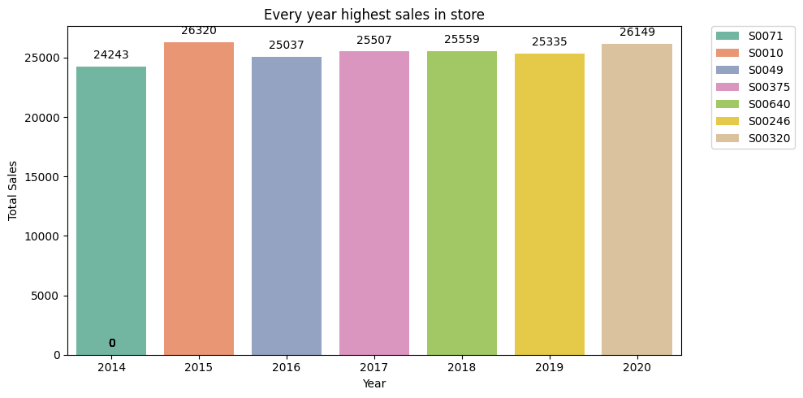

```python
plt.figure(figsize=(10, 5))
a = sns.barplot(data = top_sales_store_year[top_sales_store_year['year'] != 2021], x = 'year', hue = 'store_key', y = 'total_sales', palette='Set2')
plt.title('Every year highest sales in store')
plt.xlabel('Year')
plt.ylabel('Total Sales')

leg()
disp_val(a)

plt.tight_layout()
plt.show()
```

From the above analysis, the highest sales happened in the year **2015** in store **S0010**.

Since the data available for the 2021 is only from 1st Jan 2021 to 23rd Jan 2021, the total sales is very less. Hence, we have ignored here.

### Every year highest sold item (quantity and total price)

```python
q1 = """
select year, item_description, total_quantity_sold, total_sales_amount, q_rnk
from(
select year, item_description, total_quantity_sold, total_sales_amount,
dense_rank() over (partition by year order by total_quantity_sold desc) as q_rnk
from(
select year, item_description, sum(quantity) as total_quantity_sold, round(sum(total_price), 1) as total_sales_amount
from df
group by year, item_description
order by total_quantity_sold desc) a
) b
where q_rnk = 1
order by year
"""
total_quantity_sold = pd.read_sql_query(q1, ecom_db)
total_quantity_sold
```

|  | year | item_description | total_quantity_sold | total_sales_amount | q_rnk |
| --- | --- | --- | --- | --- | --- |
| 0 | 2014 | a. Beverage - Soda | 88879 | 877300.0 | 1 |
| 1 | 2015 | Food - Healthy | 94796 | 1497118.5 | 1 |
| 2 | 2016 | a. Beverage - Soda | 93637 | 924687.8 | 1 |
| 3 | 2017 | a. Beverage - Soda | 93508 | 916345.3 | 1 |
| 4 | 2018 | a. Beverage - Soda | 93935 | 929126.5 | 1 |
| 5 | 2019 | a. Beverage - Soda | 94702 | 933581.8 | 1 |
| 6 | 2020 | a. Beverage - Soda | 94988 | 927722.3 | 1 |
| 7 | 2021 | a. Beverage - Soda | 5698 | 55533.0 | 1 |

```python
q1 = """
select year, item_description, total_quantity_sold, total_sales_amount, q_rnk
from(
select year, item_description, total_quantity_sold, total_sales_amount,
dense_rank() over (partition by year order by total_sales_amount desc) as q_rnk
from(
select year, item_description, sum(quantity) as total_quantity_sold, round(sum(total_price), 1) as total_sales_amount
from df
group by year, item_description
order by total_sales_amount desc) a
) b
where q_rnk = 1
order by year
"""
total_sales_amount = pd.read_sql_query(q1, ecom_db)
total_sales_amount
```

|  | year | item_description | total_quantity_sold | total_sales_amount | q_rnk |
| --- | --- | --- | --- | --- | --- |
| 0 | 2014 | Food - Healthy | 88790 | 1406845.0 | 1 |
| 1 | 2015 | Food - Healthy | 94796 | 1497118.5 | 1 |
| 2 | 2016 | Food - Healthy | 92867 | 1465907.5 | 1 |
| 3 | 2017 | Food - Healthy | 92928 | 1474811.5 | 1 |
| 4 | 2018 | Food - Healthy | 93816 | 1486923.5 | 1 |
| 5 | 2019 | Food - Healthy | 93538 | 1480297.0 | 1 |
| 6 | 2020 | Food - Healthy | 93309 | 1479379.0 | 1 |
| 7 | 2021 | Food - Healthy | 5509 | 87756.0 | 1 |

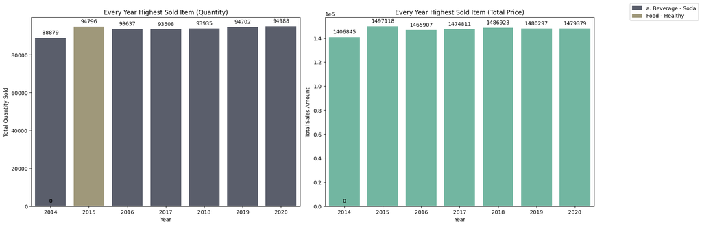

```python
fig, (ax1, ax2) = plt.subplots(1, 2, figsize=(16, 6))

sns.barplot(data=total_quantity_sold[total_quantity_sold['year'] != 2021], x='year', y='total_quantity_sold', hue='item_description', palette='cividis', ax=ax1)
ax1.set_title('Every Year Highest Sold Item (Quantity)')
ax1.set_xlabel('Year')
ax1.set_ylabel('Total Quantity Sold')
leg()
disp_val(ax1)

sns.barplot(data=total_sales_amount[total_sales_amount['year'] != 2021], x='year', y='total_sales_amount', hue='item_description', palette='Set2', ax=ax2)
ax2.set_title('Every Year Highest Sold Item (Total Price)')
ax2.set_xlabel('Year')
ax2.set_ylabel('Total Sales Amount')
leg()
disp_val(ax2)

handles, labels = ax1.get_legend_handles_labels()
fig.legend(handles, labels, bbox_to_anchor=(1.05, 1), loc='upper left', borderaxespad=0)

ax1.get_legend().remove()
ax2.get_legend().remove()

plt.tight_layout()
plt.show()
```

- From the above analysis, only 2 item categories are sold highly.
  - Beverage - Soda
  - Food - Healthy

### Division wise items sales

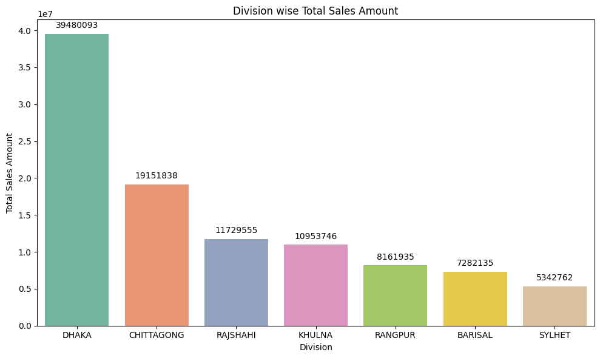

```python
div_sales = df.groupby(['division'])[['total_price', 'quantity']].sum().sort_values(by=['total_price', 'quantity'], ascending=False).reset_index()


plt.figure(figsize=(10, 6))
a = sns.barplot(data=div_sales, x='division', y='total_price', palette='Set2')
plt.title('Division wise Total Sales Amount')
plt.xlabel('Division')
plt.ylabel('Total Sales Amount')

disp_val(a)

plt.tight_layout()
plt.show()
```

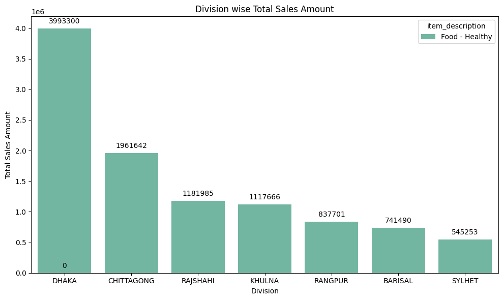

```python
q1 = """
with cte1 as (
select division, item_description, total_quantity_sold, total_sales_amount,
dense_rank() over (partition by division order by total_sales_amount desc) as s_rnk
from(
select division, item_description, sum(quantity) as total_quantity_sold, round(sum(total_price), 1) as total_sales_amount
from df
group by division, item_description ) a)

select division, item_description, total_quantity_sold, total_sales_amount
from cte1
where s_rnk = 1
order by total_sales_amount desc
"""
div_item_sales = pd.read_sql_query(q1, ecom_db)

plt.figure(figsize=(10, 6))
a = sns.barplot(data=div_item_sales, x='division', y='total_sales_amount', hue='item_description' , palette='Set2')
plt.title('Division wise Total Sales Amount')
plt.xlabel('Division')
plt.ylabel('Total Sales Amount')

disp_val(a)

plt.tight_layout()
plt.show()
```

- From the above 2 analysis, the more sales happening at Dhaka.
- Food-Healthy item is the most sold item in all the division.

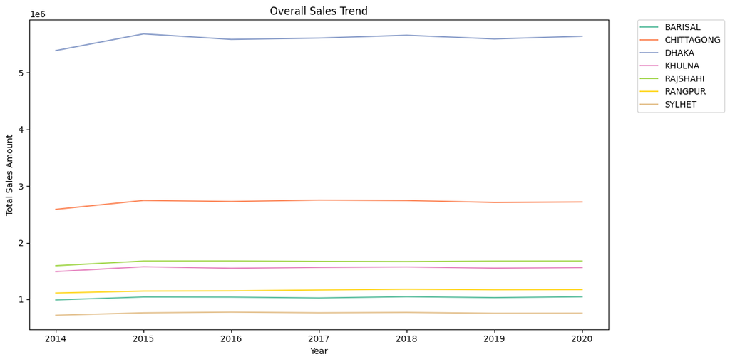

```python
overall_sales = df.groupby(['year', 'division'])['total_price'].sum().reset_index()

plt.figure(figsize=(12, 6))
sns.lineplot(data=overall_sales[overall_sales['year'] !=2021], x='year', y='total_price', hue='division', palette='Set2')
plt.title('Overall Sales Trend')
plt.xlabel('Year')
plt.ylabel('Total Sales Amount')
leg()
plt.tight_layout()
plt.show()
```

- The overall sales over the period, remains unchanged for all the divisions and seems no increase in the sales.

### Number of stores per division

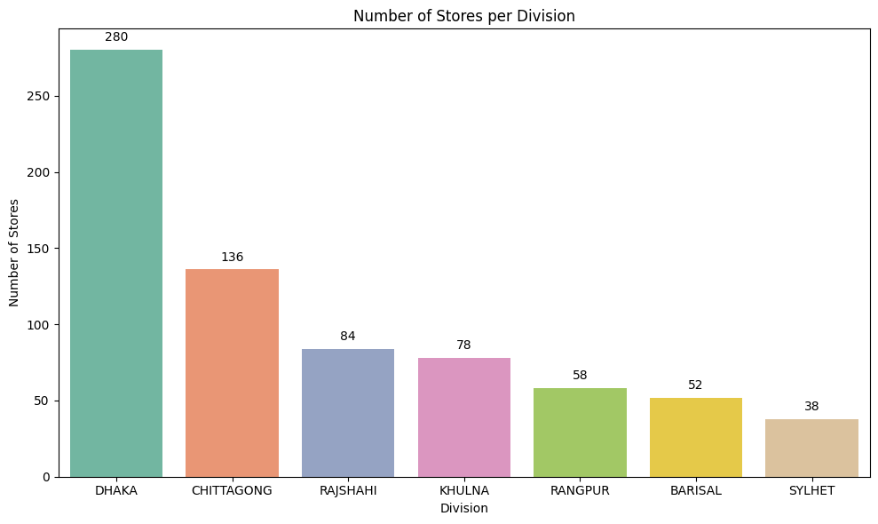

```python
store_cnt = df.groupby(['division'])['store_key'].nunique().reset_index()
store_cnt = store_cnt.sort_values(by='store_key', ascending=False)

plt.figure(figsize=(10, 6))
a = sns.barplot(data=store_cnt, x='division', y='store_key', palette='Set2')

plt.title('Number of Stores per Division')
plt.xlabel('Division')
plt.ylabel('Number of Stores')

disp_val(a)

plt.tight_layout()
plt.show()
```

- The number of stores in the divisions Sylhet, Barisal and Rangpur are very less compared to other divisions.

### Sales in Different Quarters

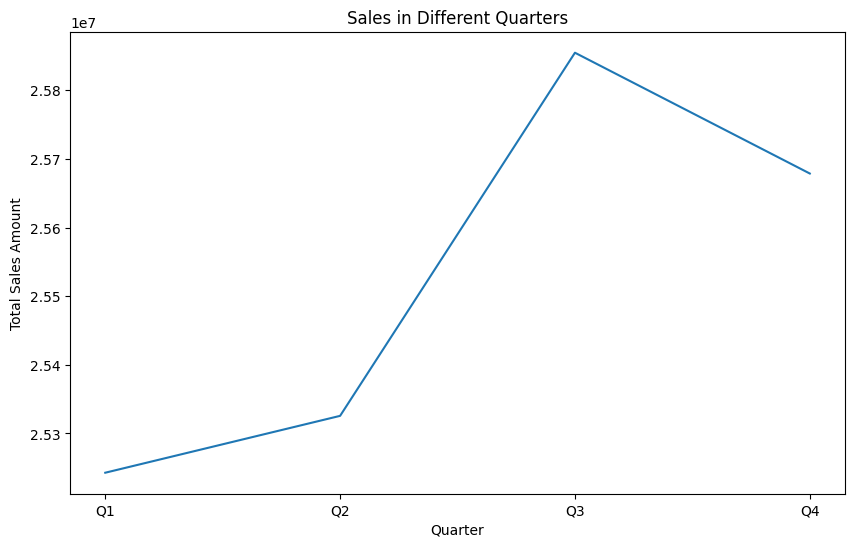

```python
quarter_sales = df.groupby('quarter')['total_price'].sum().reset_index()

plt.figure(figsize=(10, 6))
a = sns.lineplot(data=quarter_sales, x='quarter', y='total_price', palette='Set2')
disp_val(a)

plt.title('Sales in Different Quarters')
plt.xlabel('Quarter')
plt.ylabel('Total Sales Amount')
plt.show()
```

- The total sales in peak in Quarter 3 and less sales in Quarter 1.

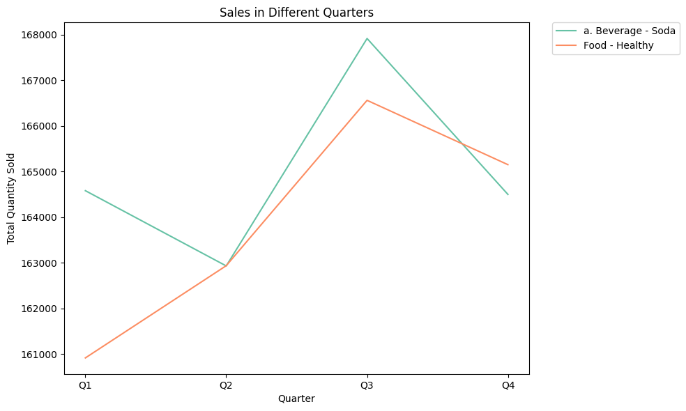

```python
q1 = """
select quarter, item_description, total_quantity_sold
from(
select quarter, item_description, total_quantity_sold,
dense_rank() over (partition by quarter order by total_quantity_sold desc) as q_rnk
from(
select quarter, item_description, sum(quantity) as total_quantity_sold
from df
group by quarter, item_description
) a
) b
where q_rnk = 1 or q_rnk = 2
order by 1
"""
quart_item_sales = pd.read_sql(q1, ecom_db)

plt.figure(figsize=(10, 6))
a = sns.lineplot(data=quart_item_sales, x='quarter', y='total_quantity_sold', hue='item_description', palette='Set2')
plt.title('Sales in Different Quarters')
plt.xlabel('Quarter')
plt.ylabel('Total Quantity Sold')

leg()

plt.tight_layout()
plt.show()
```

- The total quantities sold is at peak in Quarter 3.
- In all quarters, Beverage - Soda & Food - Healthy items are most sold.

### Monthwise sales trend

```python
df['month'] = pd.to_datetime(df['month'], format='%B').dt.month
```

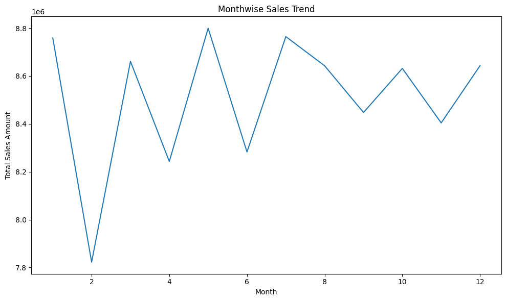

```python
month_sales = df.groupby('month')['total_price'].sum().reset_index()

plt.figure(figsize=(10, 6))
sns.lineplot(data=month_sales, x='month', y='total_price', palette='Set2')
plt.title('Monthwise Sales Trend')
plt.xlabel('Month')
plt.ylabel('Total Sales Amount')
plt.tight_layout()
plt.show()
```

### Payment methods

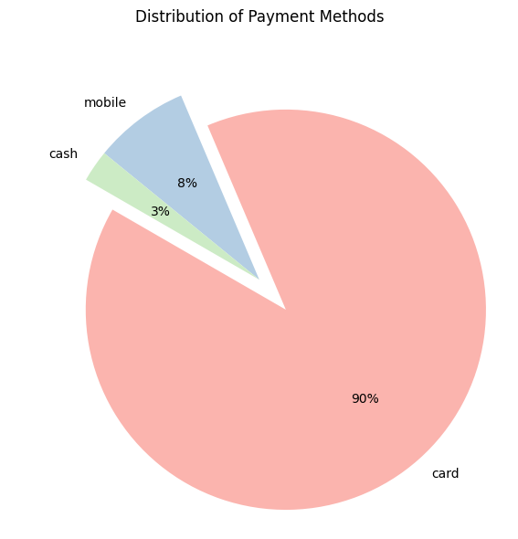

```python
pay_method = df['trans_type'].value_counts().reset_index()

explode = [0.2, 0, 0]
plt.figure(figsize=(10, 6))
plt.pie(pay_method['count'], labels=pay_method['trans_type'], autopct='%1.0f%%', explode=explode, startangle=150, colors=sns.color_palette('Pastel1'))

plt.title('Distribution of Payment Methods')
plt.tight_layout()
plt.show()
```

- Almost **90%** of the customers use card payment method for their transactions.

### Most used bank

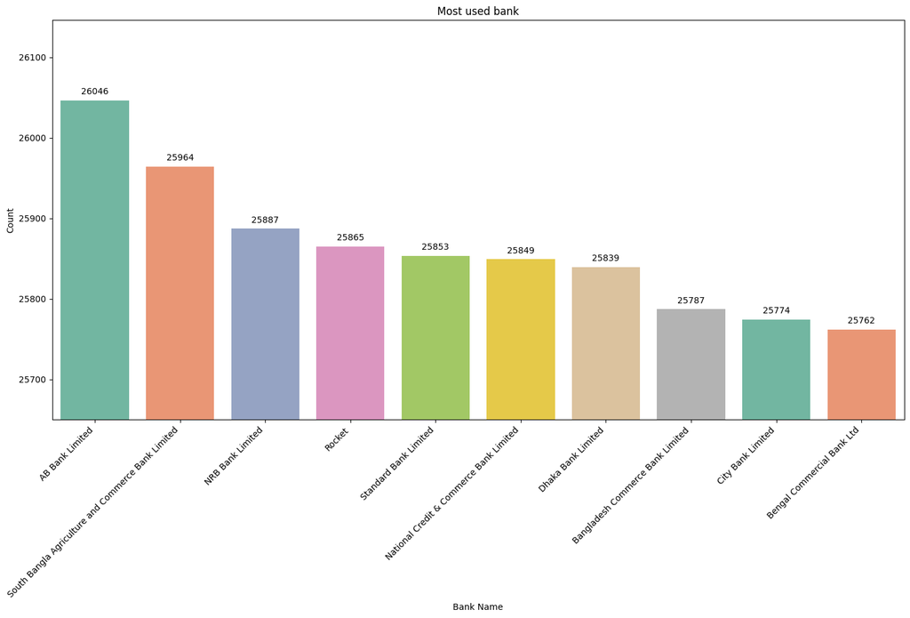

```python
bank = df['bank_name'].value_counts().reset_index().head(10)

plt.figure(figsize=(15, 10))
a = sns.barplot(data=bank, x='bank_name', y='count', palette='Set2')
disp_val(a)
plt.title('Most used bank')
plt.xlabel('Bank Name')
plt.ylabel('Count')
plt.ylim(25650, max(bank['count'])+100)
wrapped_labels = ["\n".join(bank.split(" ", 2)[:2]) for bank in bank]
plt.xticks(rotation=45, ha="right")
plt.tight_layout()
plt.show()
```

## Customer Segmentation

```python
first_date = df.groupby('customer_key')['dates'].min().reset_index()
last_date = df.groupby('customer_key')['dates'].max().reset_index()
```

```python
first_date.columns = ['customer_key', 'first_purchase_date']
last_date.columns = ['customer_key', 'last_purchase_date']
```

```python
df = df.merge(first_date, on='customer_key', how='left')
df = df.merge(last_date, on='customer_key', how='left')
```

```python
df['ref_date'] = df['dates'].max() + pd.DateOffset(days=1)
```

```python
df['recency'] = (df['ref_date'] - df['last_purchase_date']).dt.days
```

```python
df['number_of_purchase'] = df.groupby('customer_key')['customer_key'].transform('count')
```

```python
df['tot_month'] = round((df['last_purchase_date'] - df['first_purchase_date']).dt.days/30, 0)
```

```python
df['frequency'] = round(df['number_of_purchase'] / df['tot_month'], 2)
df['monetary'] = round(df.groupby('customer_key')['total_price'].transform('sum'), 2)
```

```python
m20 = df['monetary'].quantile(0.20)
m40 = df['monetary'].quantile(0.40)
m60 = df['monetary'].quantile(0.60)
m80 = df['monetary'].quantile(0.80)
m100 = df['monetary'].quantile(1)
m20, m40, m60, m80, m100
```

```
(10130.38, 10842.5, 11507.0, 12274.75, 16320.75)
```

```python
f20 = df['frequency'].quantile(0.20)
f40 = df['frequency'].quantile(0.40)
f60 = df['frequency'].quantile(0.60)
f80 = df['frequency'].quantile(0.80)
f100 = df['frequency'].quantile(1)
f20, f40, f60, f80, f100
```

```
(1.2, 1.28, 1.34, 1.42, 1.86)
```

```python
r20 = df['recency'].quantile(0.20)
r40 = df['recency'].quantile(0.40)
r60 = df['recency'].quantile(0.60)
r80 = df['recency'].quantile(0.80)
r100 = df['recency'].quantile(1)
r20, r40, r60, r80, r100
```

```
(7.0, 14.0, 23.0, 39.0, 218.0)
```

```python
df['m_score'] = pd.cut(df['monetary'], bins=[0, m20, m40, m60, m80, m100], labels=[1, 2, 3, 4, 5])
df['f_score'] = pd.cut(df['frequency'], bins=[0, f20, f40, f60, f80, f100], labels=[1, 2, 3, 4, 5])
df['r_score'] = pd.cut(df['recency'], bins=[0, r20, r40, r60, r80, r100], labels=[5, 4, 3, 2, 1])
```

```python
df['fm_score'] = round((df['m_score'].astype(int) + df['f_score'].astype(int)) / 2, 0)
```

```python
def cust_seg(r, fm):
  if (r == 5 and fm == 5) or (r == 5 and fm == 4) or  (r == 4 and fm == 5):
    return 'Champions'
  elif (r == 5 and fm == 3) or (r == 4 and fm == 4) or  (r == 3 and fm == 5) or (r == 3 and fm == 4):
    return 'Loyal Customers'
  elif (r == 5 and fm == 2) or (r == 4 and fm == 2) or  (r == 3 and fm == 3) or (r == 4 and fm == 3):
    return 'Potential Loyalists'
  elif (r == 5 and fm == 1):
    return 'Recent Customers'
  elif (r == 4 and fm == 1) or (r == 3 and fm == 1):
    return 'Promising'
  elif (r == 3 and fm == 2) or (r == 2 and fm == 3) or (r == 2 and fm == 2):
    return 'Customers Needing Attention'
  elif (r == 2 and fm == 4) or (r == 2 and fm == 5) or (r == 1 and fm == 3):
    return 'At Risk'
  elif (r == 1 and fm == 5) or (r == 1 and fm == 4):
    return 'Cant Lose Them'
  elif (r == 1 and fm == 2) or (r == 1 and fm == 1) or (r == 2 and fm == 1):
    return 'Hibernating'
  elif (r == 1 and fm == 1):
    return 'Lost'
  else:
    return r,fm
```

```python
df['rfm_segment'] = df.apply(lambda x: cust_seg(x['r_score'], x['fm_score']), axis=1)
```

```python
df['rfm_segment'].value_counts().reset_index()
```

|  | rfm_segment | count |
| --- | --- | --- |
| 0 | Potential Loyalists | 176063 |
| 1 | Loyal Customers | 166242 |
| 2 | Customers Needing Attention | 148114 |
| 3 | Champions | 119888 |
| 4 | Hibernating | 116854 |
| 5 | At Risk | 109725 |
| 6 | Cant Lose Them | 84745 |
| 7 | Promising | 50446 |
| 8 | Recent Customers | 27923 |

```python
df.to_csv('df_rfm.csv', index=False)
```

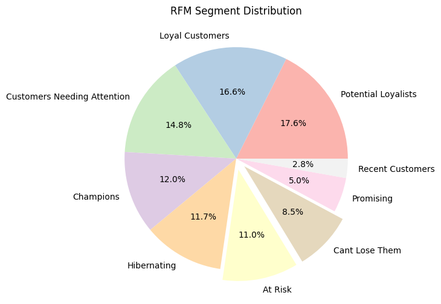

```python
sizes = df['rfm_segment'].value_counts()
labels = sizes.index
explode = [0, 0, 0, 0, 0, 0.1, 0.1, 0, 0]

plt.figure(figsize=(8, 6))
plt.pie(sizes, labels=labels, autopct='%1.1f%%',  explode=explode, startangle=0, colors=sns.color_palette('Pastel1'))
plt.title("RFM Segment Distribution")
plt.show()
```

- There are **11%** of customers who are at **Risk** segement, need to make them purchase frequently.
- There are **8.5%** of customers who are at **Can't lose them** segment, need to win them back.

# Exploratory Data Analysis

## Normality test

### QQ plot

```python
import statsmodels.api as sm
```

```python
num_cols = ['total_price', 'quantity', 'recency', 'number_of_purchase', 'frequency', 'monetary', 'unit_price']
```

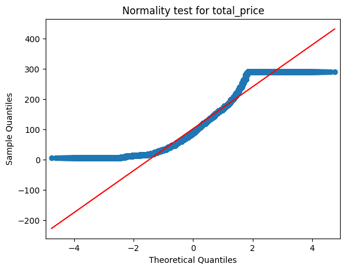

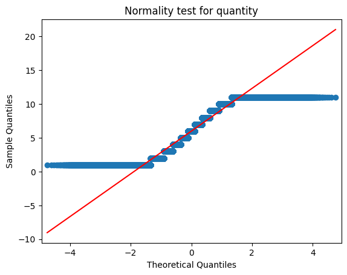

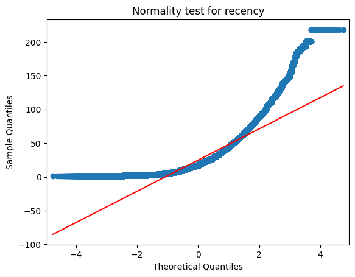

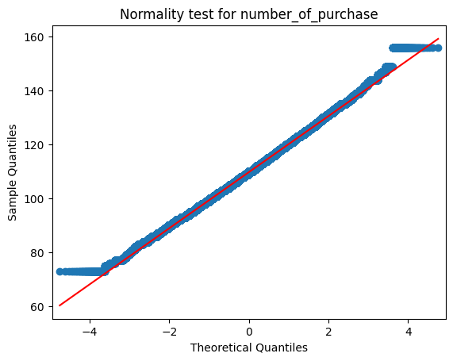

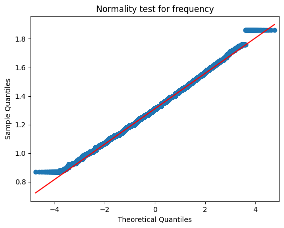

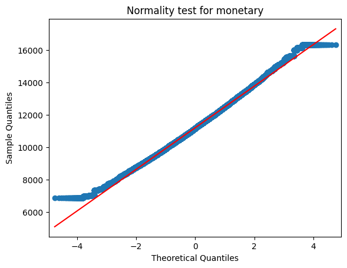

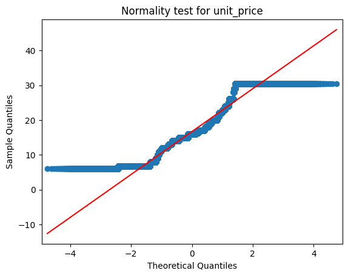

```python
for col in num_cols:
  a = np.array(df[col])
  sm.qqplot(a, line="s")
  plt.title(f"Normality test for {col}")
  plt.show()
```

### Shapiro-Wilk test

```python
from scipy.stats import shapiro
```

```python
for col in num_cols:
  a = np.array(df[col])
  stat, pvalue = shapiro(a)
  print(f"{col} : {pvalue}; Not normally distributed" if pvalue <= 0.05 else ";\t\t\tNormally distributed\n")
```

```
total_price : 8.958389509258947e-144; Not normally distributed
quantity : 1.0115475064741086e-138; Not normally distributed
recency : 9.258991473465387e-174; Not normally distributed
number_of_purchase : 7.526419825183871e-49; Not normally distributed
frequency : 3.646155091653796e-48; Not normally distributed
monetary : 4.1539248217887104e-50; Not normally distributed
unit_price : 1.2827231666404496e-139; Not normally distributed
```

## Data transformation for normalization

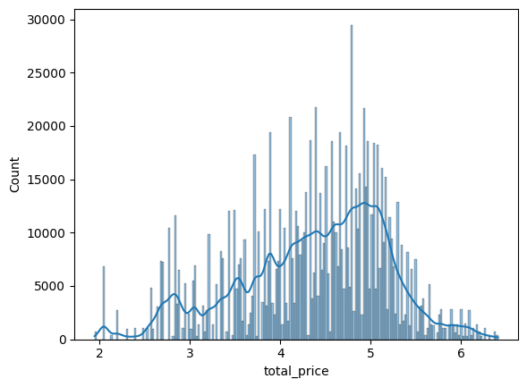

```python
df1['total_price'] = np.log1p(df1['total_price'])
sns.histplot(data=df1['total_price'], kde=True)
plt.show()
```

[output not shown]

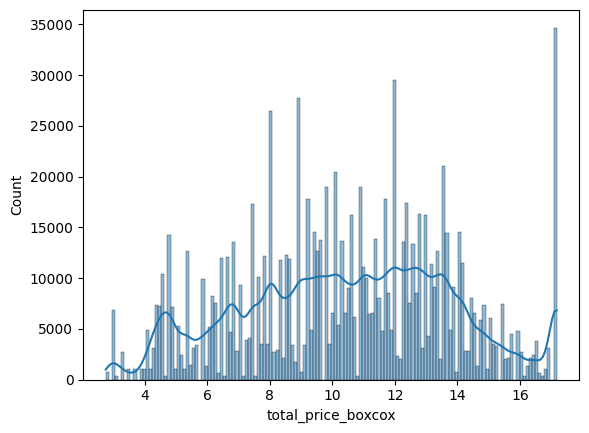

```python
from scipy.stats import boxcox

df1["total_price_boxcox"], lambda_val = boxcox(df["total_price"] + 1)
print("After Box-Cox transformation:", df1["total_price_boxcox"].skew())
print(f"Best lambda value: {lambda_val}")
sns.histplot(data=df1['total_price_boxcox'], kde=True)
plt.show()
```

[output not shown]

- After the transformation, the data set is still not normally distributed.

## Kruskal-Wallis test (compare the total sales among different years)

```python
from scipy.stats import kruskal
```

```python
sales_2014 = df[df['year'] == 2014]['total_price']
sales_2015 = df[df['year'] == 2015]['total_price']
sales_2016 = df[df['year'] == 2016]['total_price']
sales_2017 = df[df['year'] == 2017]['total_price']
sales_2019 = df[df['year'] == 2018]['total_price']
sales_2019 = df[df['year'] == 2019]['total_price']
sales_2020 = df[df['year'] == 2020]['total_price']
```

```python
stat, p_value = kruskal(
    sales_2014,
    sales_2015,
    sales_2016,
    sales_2017,
    sales_2019,
    sales_2019,
    sales_2020
)

print(f'Statistic: {stat}')
print(f'P-Value: {p_value}')

if p_value < 0.05:
   print("Reject H0")
   print("At least one of the medians of the total price is different among the other sales year.")
else:
   print("Fail to reject H0")
   print("The medians of the total price are the same for all the sales years.")
```

```
Statistic: 1.1997009367452445
P-Value: 0.9768994813158671
Fail to reject H0
The medians of the total price are the same for all the sales years.
```

## Chi-Squared test

```python
from scipy.stats import chi2_contingency
```

### Payment methods vs customers

- Null Hypothesis (H0): Payment methods are equally distributed among customers.
- Alternative Hypothesis (H1): Payment methods are not equally distributed among customers.

```python
payment_counts = pd.crosstab(df['trans_type'], df['customer_key'])

chi2_stat, p_value, dof, expected = chi2_contingency(payment_counts)

print(f"Chi-Square Statistic: {chi2_stat}, P-Value: {p_value}")

if p_value < 0.05:
    print("Reject H0: Payment methods are not equally distributed among customers.")
else:
    print("Fail to Reject H0: Payment methods are equally distributed among customers.")
```

```
Chi-Square Statistic: 17907.371069052442, P-Value: 0.993486971758989
Fail to Reject H0: Payment methods are equally distributed among customers.
```

### Items vs customers

- H0 (Null Hypothesis): There is no relationship between items and customers (i.e., all customers purchase items randomly).
- H1 (Alternative Hypothesis): There is a significant relationship between items and customers (i.e., some customers prefer certain item categories).

```python
contingency_table = pd.crosstab(df["item_key"], df["customer_key"])

chi2, p, dof, expected = chi2_contingency(contingency_table)

print(f"Chi-Square Statistic: {chi2:.2f}")
print(f"P-Value: {p:.5f}")

if p < 0.05:
    print("Reject H0: There is a significant relationship between items and customers.")
else:
    print("Fail to Reject H0: No significant relationship found.")
```

```
Chi-Square Statistic: 2419231.36
P-Value: 0.15185
Fail to Reject H0: No significant relationship found.
```

### Items vs customers segment

- H0 (Null Hypothesis): There is no relationship between items and customer segments (i.e., all customers purchase items randomly).
- H1 (Alternative Hypothesis): There is a significant relationship between items and customer segments (i.e., some customers prefer certain items).

```python
contingency_table = pd.crosstab(df["item_key"], df["rfm_segment"])

chi2, p, dof, expected = chi2_contingency(contingency_table)

print(f"Chi-Square Statistic: {chi2:.2f}")
print(f"P-Value: {p:.5f}")

if p < 0.05:
    print("Reject H0: There is a significant relationship between items and customer segments.")
else:
    print("Fail to Reject H0: No significant relationship found.")
```

```
Chi-Square Statistic: 2366.16
P-Value: 0.00005
Reject H0: There is a significant relationship between items and customer segments.
```

```python
contingency_table = pd.crosstab(df["item_description"], df["rfm_segment"])

chi2, p, dof, expected = chi2_contingency(contingency_table)

print(f"Chi-Square Statistic: {chi2:.2f}")
print(f"P-Value: {p:.5f}")

if p < 0.05:
    print("Reject H0: There is a significant relationship between items and customer segments.")
else:
    print("Fail to Reject H0: No significant relationship found.")
```

```
Chi-Square Statistic: 420.37
P-Value: 0.00000
Reject H0: There is a significant relationship between items and customer segments.
```

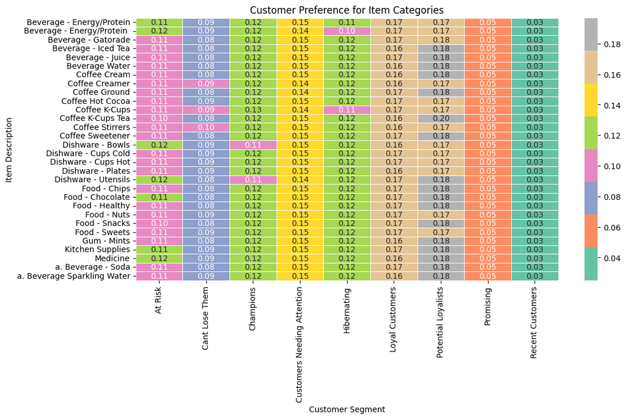

```python
contingency_percent = contingency_table.div(contingency_table.sum(axis=1), axis=0)

plt.figure(figsize=(12, 6))
sns.heatmap(contingency_percent, cmap="Set2", annot=True, fmt=".2f", linewidths=0.5)

plt.title("Customer Preference for Item Categories")
plt.xlabel("Customer Segment")
plt.ylabel("Item Description")
plt.show()
```

### Manufacturing country vs customers

- H0 (Null Hypothesis): There is no relationship between manufacturing countries and customers (i.e., all customers purchase items randomly from the manufacturing countries).
- H1 (Alternative Hypothesis): There is a significant relationship between manufacturing and customers (i.e., some customers prefer certain manufacturing countries).

```python
contingency_table = pd.crosstab(df["man_country"], df["customer_key"])

chi2, p, dof, expected = chi2_contingency(contingency_table)

print(f"Chi-Square Statistic: {chi2:.2f}")
print(f"P-Value: {p:.5f}")

if p < 0.05:
    print("Reject H0: There is a significant relationship between manufacturing country and customers.")
else:
    print("Fail to Reject H0: No significant relationship found.")
```

```
Chi-Square Statistic: 82891.40
P-Value: 0.32732
Fail to Reject H0: No significant relationship found.
```

```python
contingency_table = pd.crosstab(df["man_country"], df["rfm_segment"])

chi2, p, dof, expected = chi2_contingency(contingency_table)

print(f"Chi-Square Statistic: {chi2:.2f}")
print(f"P-Value: {p:.5f}")

if p < 0.05:
    print("Reject H0: There is a significant relationship between manufacturing country and customer segments.")
else:
    print("Fail to Reject H0: No significant relationship found.")
```

```
Chi-Square Statistic: 65.17
P-Value: 0.70265
Fail to Reject H0: No significant relationship found.
```

### Item vs month

- H0 (Null Hypothesis): There is no relationship between months and items (i.e., all items are sold randomly in all months).
- H1 (Alternative Hypothesis): There is a significant relationship between months and items (i.e., some items sold particularly in some months).

```python
contingency_table = pd.crosstab(df["month"], df["item_key"])

chi2, p, dof, expected = chi2_contingency(contingency_table)

print(f"Chi-Square Statistic: {chi2:.2f}")
print(f"P-Value: {p:.5f}")

if p < 0.05:
    print("Reject H0: There is a significant relationship between months and items.")
else:
    print("Fail to Reject H0: No significant relationship found.")
```

```
Chi-Square Statistic: 3025.67
P-Value: 0.04209
Reject H0: There is a significant relationship between months and items.
```

```python
contingency_table = pd.crosstab(df["month"], df["item_description"])

chi2, p, dof, expected = chi2_contingency(contingency_table)

print(f"Chi-Square Statistic: {chi2:.2f}")
print(f"P-Value: {p:.5f}")

if p < 0.05:
    print("Reject H0: There is a significant relationship between months and items.")
else:
    print("Fail to Reject H0: No significant relationship found.")
```

```
Chi-Square Statistic: 351.77
P-Value: 0.10001
Fail to Reject H0: No significant relationship found.
```

### Items vs quarters

- H0 (Null Hypothesis): There is no relationship between quarters and items (i.e., all items are sold randomly in all quarters).
- H1 (Alternative Hypothesis): There is a significant relationship between quarters and items (i.e., some items sold particularly in some quarters).

```python
contingency_table = pd.crosstab(df["quarter"], df["item_key"])

chi2, p, dof, expected = chi2_contingency(contingency_table)

print(f"Chi-Square Statistic: {chi2:.2f}")
print(f"P-Value: {p:.5f}")

if p < 0.05:
    print("Reject H0: There is a significant relationship between quarters and items.")
else:
    print("Fail to Reject H0: No significant relationship found.")
```

```
Chi-Square Statistic: 802.37
P-Value: 0.36261
Fail to Reject H0: No significant relationship found.
```

```python
contingency_table = pd.crosstab(df["quarter"], df["item_description"])

chi2, p, dof, expected = chi2_contingency(contingency_table)

print(f"Chi-Square Statistic: {chi2:.2f}")
print(f"P-Value: {p:.5f}")

if p < 0.05:
    print("Reject H0: There is a significant relationship between quarters and items.")
else:
    print("Fail to Reject H0: No significant relationship found.")
```

```
Chi-Square Statistic: 88.06
P-Value: 0.44808
Fail to Reject H0: No significant relationship found.
```

### Item vs divisions

- H0 (Null Hypothesis): There is no relationship between divisions and items (i.e., all items are sold randomly in all divisions).
- H1 (Alternative Hypothesis): There is a significant relationship between quarters and items (i.e., some items sold particularly in some divisions).

```python
contingency_table = pd.crosstab(df["division"], df["item_description"])

chi2, p, dof, expected = chi2_contingency(contingency_table)

print(f"Chi-Square Statistic: {chi2:.2f}")
print(f"P-Value: {p:.5f}")

if p < 0.05:
    print("Reject H0: There is a significant relationship between divisions and items.")
else:
    print("Fail to Reject H0: No significant relationship found.")
```

```
Chi-Square Statistic: 156.29
P-Value: 0.82829
Fail to Reject H0: No significant relationship found.
```

```python
contingency_table = pd.crosstab(df["division"], df["item_key"])

chi2, p, dof, expected = chi2_contingency(contingency_table)

print(f"Chi-Square Statistic: {chi2:.2f}")
print(f"P-Value: {p:.5f}")

if p < 0.05:
    print("Reject H0: There is a significant relationship between divisions and items.")
else:
    print("Fail to Reject H0: No significant relationship found.")
```

```
Chi-Square Statistic: 1559.89
P-Value: 0.62239
Fail to Reject H0: No significant relationship found.
```

# Key Insights & Recommendations

## 1. Sales Trends and Performance

- Highest sales occurred in 2015, with store S0010 leading in revenue.
- No significant growth trend in overall sales over the years.
- Sales peak in Q3 (July-Sept), while Q1 has the lowest sales.
- Dhaka has the highest sales, while Sylhet, Barisal, and Rangpur have the lowest.

**Recommendations:**

- Target Q1 promotions to boost sales during slow months.
- Expand store presence in low-sales divisions (Sylhet, Barisal, Rangpur).

## 2. Best-Selling Products

Only two product categories dominate sales:

- Beverage - Soda
- Food - Healthy

These items consistently rank highest across all years, quarters and divisions.

**Recommendations:**

- Diversify the product range to reduce dependence on a few items.
- Increase inventory of top-performing products in high-demand regions.

## 3. Customer Behavior and Segmentation (RFM Analysis)

**Recommendations:**

- Re-engagement campaigns (discounts, personalized offers) for "At Risk" customers.
- Loyalty programs for "Champions" and "Loyal Customers" to maintain retention.
- Special incentives for "Can't Lose Them" to bring them back.

## 4. Payment Method Analysis

- 90% of transactions use card payments, while mobile and cash payments are much lower.

**Recommendation:**

- Promote mobile payments with extra discounts to encourage usage.
- Identify if cash users have specific characteristics (e.g., older customers) and adapt marketing.

## 5. Bank Preferences

**Recommendation:**

- Partner with top banks to offer exclusive discounts for their cardholders.
- Encourage partnerships with underused banks to increase customer reach.

## 6. Customer Preferences Based on Item and Location

**Recommendation:**

- Region-specific marketing (e.g., tailor promotions based on local preferences).
- Use customer segment data to personalize product recommendations.

## 7. Short-Term Actions

- Boost sales in Q1 (slowest quarter) with limited-time discounts.
- Re-engage "At Risk" customers through loyalty offers and targeted email campaigns.
- Strengthen partnerships with top banks to increase transaction volume.

## 8. Long-Term Actions

- Expand store presence in underperforming regions.
- Diversify product offerings beyond Beverage-Soda and Food-Healthy.
- Increase adoption of mobile payments via cashback rewards.